# games

#### Прибыльность и популярность жанров

Далее составим рейтинг наиболее выпускаемых и наиболее продоваемых жанров видеоигр

```python
#Составим свожную таблицу, содержащую информацию о количестве релизов внутри каждого жанра)
top_release_genres = (
    pd.pivot_table(games_actual, index = "genre", aggfunc="count")
    .reset_index()
    .sort_values(by="name", ascending=False)
)

top_release_genres.loc[:, ["genre", "name"]]
```

|  | genre | name |
| --- | --- | --- |
| 0 | Action | 619 |
| 7 | Role-Playing | 221 |
| 1 | Adventure | 185 |
| 10 | Sports | 161 |
| 8 | Shooter | 128 |
| 3 | Misc | 113 |
| 6 | Racing | 69 |
| 2 | Fighting | 60 |
| 9 | Simulation | 44 |
| 4 | Platform | 38 |
| 11 | Strategy | 37 |
| 5 | Puzzle | 14 |

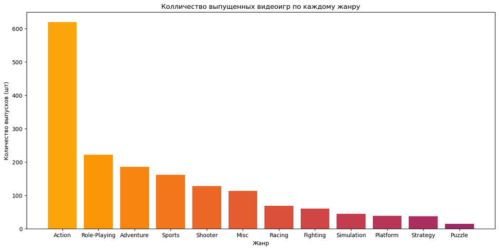

```python
#По предыдущей таблице выведем столбчатую диаграмму
fig, ax = plt.subplots(figsize=(15, 7))
color = cm.inferno(np.linspace(.8, .15, 20))

plt.bar("genre", "name", data=top_release_genres, color=color)
plt.xlabel("Жанр")
plt.ylabel("Количество выпусков (шт)")
plt.title("Колличество выпущенных видеоигр по каждому жанру")

plt.show ()
```

```python
#Аналогично составим сводную таблицу с продоваемостью внутри каждого жанра
top_sales_genres = (
    pd.pivot_table(games_actual, index = "genre", values = "sum_sales", aggfunc="sum")
    .reset_index()
    .sort_values(by="sum_sales", ascending=False)
)

top_sales_genres
```

|  | genre | sum_sales |
| --- | --- | --- |
| 0 | Action | 199.36 |
| 8 | Shooter | 170.94 |
| 10 | Sports | 109.48 |
| 7 | Role-Playing | 101.44 |
| 3 | Misc | 37.55 |
| 2 | Fighting | 28.22 |
| 6 | Racing | 27.52 |
| 4 | Platform | 18.09 |
| 1 | Adventure | 17.55 |
| 9 | Simulation | 13.13 |
| 11 | Strategy | 3.96 |
| 5 | Puzzle | 2.21 |

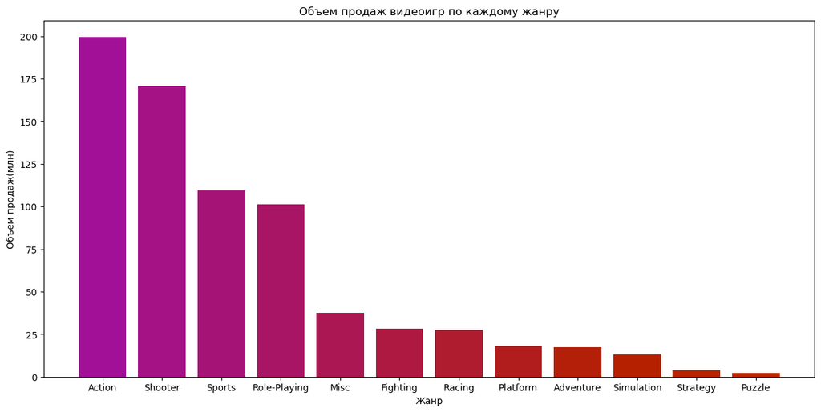

```python
#И выведем столбчатую диаграмму по данной таблице
fig, ax = plt.subplots(figsize=(15, 7))
color = cm.gnuplot(np.linspace(.4, .8, 35))

plt.bar("genre", "sum_sales", data=top_sales_genres, color=color)
plt.xlabel("Жанр")
plt.ylabel("Объем продаж(млн)")
plt.title("Объем продаж видеоигр по каждому жанру")

plt.show()
```

```python
#Составим табллицу с данными по продажам для построения диаграммы размаха
box_sales = games_actual.loc[games_actual["genre"].isin(list(top_sales_genres["genre"]))]
box_sales = box_sales[["genre", "sum_sales"]]
box_sales = box_sales.set_index('genre')
```

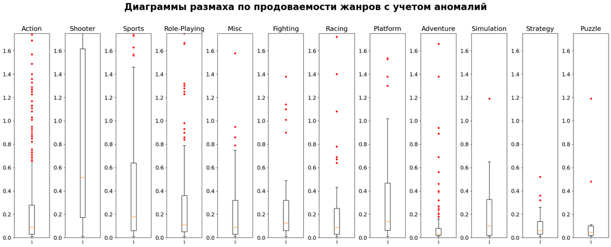

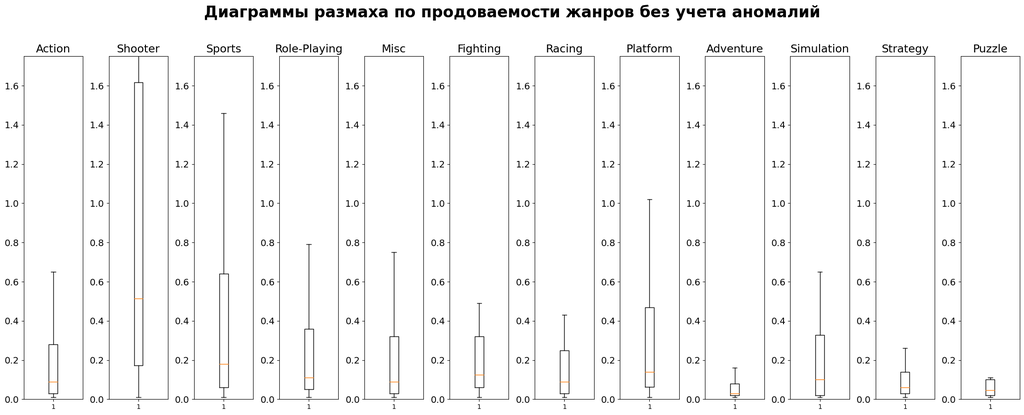

```python
#Устанавливаем цвет и маркер для обозначения выбросов
red_circle = dict(markerfacecolor='red', marker='o', markeredgecolor='white')


plat = list(top_sales_genres["genre"])

#Создаем поле для графика
fig, axs = plt.subplots(1, len(list(top_sales_genres["genre"])), figsize=(22, 9))
fig.suptitle('Диаграммы размаха по продоваемости жанров с учетом аномалий' + '\n', fontsize=24, fontweight='bold')

#Строим графики по каждой из платформ за выделенный период
for i, ax in enumerate(axs.flat):
    ax.boxplot(box_sales.loc[plat[i]], flierprops = red_circle, data=box_sales)
    ax.set_title(plat[i], fontsize=17)
    ax.tick_params(axis="y", labelsize=14)
    ax.set_ylim([0, 1.75])

plt.tight_layout()



fig, axs = plt.subplots(1, len(list(top_sales_genres["genre"])), figsize=(22, 9))
fig.suptitle('Диаграммы размаха по продоваемости жанров без учета аномалий' + '\n', fontsize=24, fontweight='bold')

#Строим графики по каждой из платформ за выделенный период
for i, ax in enumerate(axs.flat):
    ax.boxplot(box_sales.loc[plat[i]], flierprops = red_circle, data=box_sales, showfliers=False)
    ax.set_title(plat[i], fontsize=17)
    ax.tick_params(axis="y", labelsize=14)
    ax.set_ylim([0, 1.75])


plt.tight_layout()
```

[output not shown]

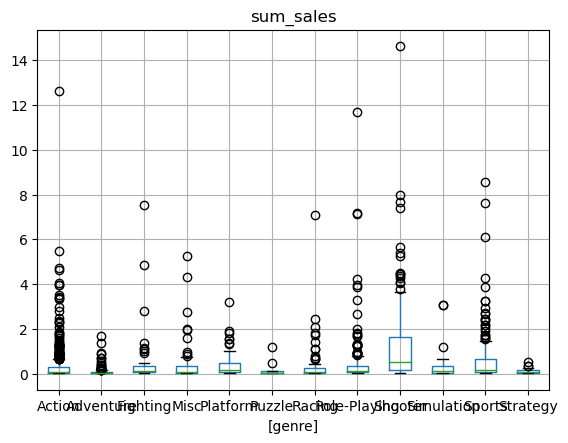

```python
# check
# график без оформления ...

games_actual[['sum_sales','genre']].boxplot(by='genre')
plt.suptitle("");
```

Таким образом в рамках данного блока удалось составить рейтинг самых выпускаемых и продоваемых жанров, в которых верхушку занимают шутеры и аркады, будучи самыми прибыльными, на второй ступени спортивные и ролевые игры. Также выпускаются миски и платформы, но их продоваемость на рынке куда менее стабильна и высока.

### Портрет среднестатистического пользователя видеоигр по регионам

#### Топ платформ по продажам в трех регионах

```python
north_america = (
    games_actual.groupby("platform")
    .agg({"na_sales":"sum"})
    .sort_values(by="na_sales", ascending=False)
    .reset_index(0))

display(north_america)

#А  также сгруппируем таблтцу, прревратив рейтинг в топ-5
north_america.loc[north_america.index > 4, 'platform'] = "other"
display(north_america)
north_america = pd.pivot_table(north_america, index = "platform").reset_index(0)
display(north_america)
```

|  | platform | na_sales |
| --- | --- | --- |
| 0 | PS4 | 98.61 |
| 1 | XOne | 81.27 |
| 2 | X360 | 28.30 |
| 3 | 3DS | 22.64 |
| 4 | PS3 | 22.05 |
| 5 | WiiU | 19.36 |
| 6 | PC | 7.23 |
| 7 | PSV | 2.52 |
| 8 | Wii | 2.08 |
| 9 | PSP | 0.00 |

|  | platform | na_sales |
| --- | --- | --- |
| 0 | PS4 | 98.61 |
| 1 | XOne | 81.27 |
| 2 | X360 | 28.30 |
| 3 | 3DS | 22.64 |
| 4 | PS3 | 22.05 |
| 5 | other | 19.36 |
| 6 | other | 7.23 |
| 7 | other | 2.52 |
| 8 | other | 2.08 |
| 9 | other | 0.00 |

|  | platform | na_sales |
| --- | --- | --- |
| 0 | 3DS | 22.64 |
| 1 | PS3 | 22.05 |
| 2 | PS4 | 98.61 |
| 3 | X360 | 28.30 |
| 4 | XOne | 81.27 |
| 5 | other | 6.24 |

```python
#Сделаем срезы данных из основного массива, которые будут содержать информацию только по суммарным продажам в отдельном регионе
#по каждой платформе
north_america = (
    games_actual.groupby("platform")
    .agg({"na_sales":"sum"})
    .sort_values(by="na_sales", ascending=False)
    .reset_index(0))

#А  также сгруппируем таблтцу, прревратив рейтинг в топ-5
north_america.loc[north_america.index > 4, 'platform'] = "other"
north_america = pd.pivot_table(north_america, index = "platform", aggfunc="sum").reset_index(0)

#Далее аналогично

europe = (
    games_actual.groupby("platform")
    .agg({"eu_sales":"sum"})
    .sort_values(by="eu_sales", ascending=False)
    .reset_index(0))

europe.loc[europe.index > 4, 'platform'] = "other"
europe = pd.pivot_table(europe, index = "platform", aggfunc="sum").reset_index(0)

japan = (
    games_actual
    .groupby("platform")
    .agg({"jp_sales":"sum"})
    .sort_values(by="jp_sales", ascending=False)
    .reset_index(0))

japan.loc[japan.index > 4, 'platform'] = "other"
japan = pd.pivot_table(japan, index = "platform", aggfunc="sum").reset_index(0)
```

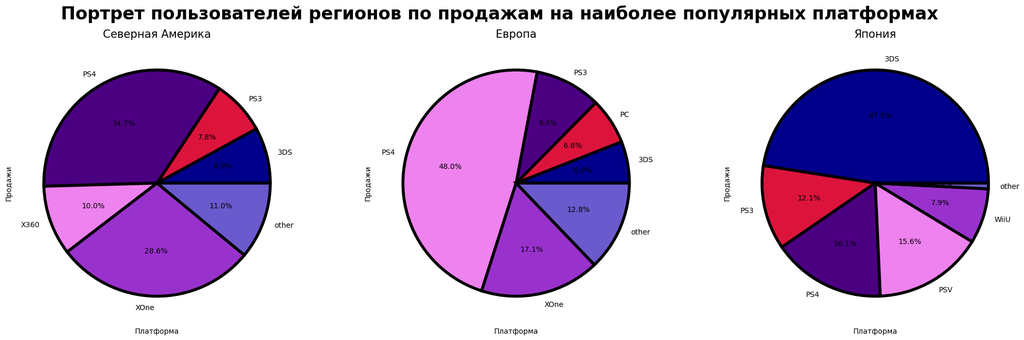

```python
#Выведим три графика распределения продаж между платформами по каждому региону

#Задаем цвета и массивы
regions = [north_america, europe, japan]
reg_data = ["na_sales", "eu_sales", "jp_sales"]
colours = ("darkblue", "crimson", "indigo", "violet", "darkorchid", "slateblue")
names = ["Северная Америка", "Европа", "Япония"]


fig, axs = plt.subplots(1, 3, figsize=(25, 7))
fig.suptitle('Портрет пользователей регионов по продажам на наиболее популярных платформах' + '\n', fontsize=24, fontweight='bold')

for i, ax in enumerate(axs.flat):
    ax.pie(reg_data[i], labels=list(regions[i]["platform"]), autopct='%1.1f%%', colors = colours, data=regions[i], wedgeprops={"edgecolor":"k",'linewidth': 4, 'linestyle': '-', 'antialiased': True})
    ax.set_ylabel('Продажи')
    ax.set_xlabel('Платформа')
    ax.set_title(names[i])
    ax.title.set_size(15)

plt.show()
```

Так, можно заметить, что списки Европы и Америки похожи, поскольку это регионы со схожей культурой и, соответствено, со схожим рынком. Япония как страна азиатского происхождения имеет свой рынок, на котороп PS и Xbox в первую очередь заменяет 3DS

#### Топ жанров по продажам в трех регионах

```python
#Сделаем срезы данных из основного массива, которые будут содержать информацию только по суммарным продажам в отдельном регионе
#по каждому жанру
north_america_genre = (
    games_actual.groupby("genre")
    .agg({"na_sales":"sum"})
    .sort_values(by="na_sales", ascending=False)
    .reset_index(0))

north_america_genre.loc[north_america_genre.index > 4, 'genre'] = "other"
north_america_genre = pd.pivot_table(north_america_genre, index = "genre", aggfunc="sum").reset_index(0)

europe_genre = (
    games_actual.groupby("genre")
    .agg({"eu_sales":"sum"})
    .sort_values(by="eu_sales", ascending=False)
    .reset_index(0))

europe_genre.loc[europe_genre.index > 4, 'genre'] = "other"
europe_genre = pd.pivot_table(europe_genre, index = "genre", aggfunc="sum").reset_index(0)

japan_genre = (
    games_actual
    .groupby("genre")
    .agg({"jp_sales":"sum"})
    .sort_values(by="jp_sales", ascending=False)
    .reset_index(0))

japan_genre.loc[japan_genre.index > 4, 'genre'] = "other"
japan_genre = pd.pivot_table(japan_genre, index = "genre", aggfunc="sum").reset_index(0)
```

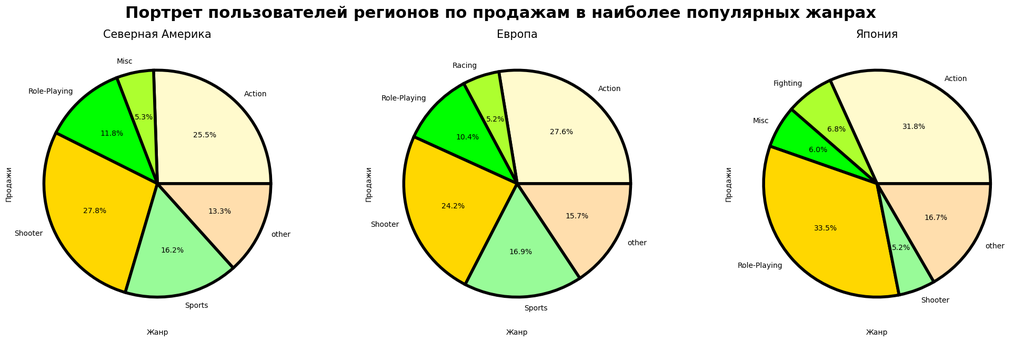

```python
#Выведим три графика распределения продаж между платформами по каждому региону

#Задаем цвета и массивы
regions_genre = [north_america_genre, europe_genre, japan_genre]
reg_data = ["na_sales", "eu_sales", "jp_sales"]
names = ["Северная Америка", "Европа", "Япония"]
pie_chart_colors = ('lemonchiffon', 'greenyellow', 'lime', "gold", "palegreen", "navajowhite")


fig, axs = plt.subplots(1, 3, figsize=(25, 7))
fig.suptitle('Портрет пользователей регионов по продажам в наиболее популярных жанрах' + '\n', fontsize=22, fontweight='bold')

for i, ax in enumerate(axs.flat):
    ax.pie(reg_data[i], labels=list(regions_genre[i]["genre"]), autopct='%1.1f%%', colors = pie_chart_colors, data=regions_genre[i], wedgeprops={"edgecolor":"k",'linewidth': 4, 'linestyle': '-', 'antialiased': True})
    ax.set_ylabel('Продажи')
    ax.set_xlabel('Жанр')
    ax.set_title(names[i])
    ax.title.set_size(15)

plt.show()
```

Япония снова отличилась :)

#### Влияние ESRB на продажи по регионам

```python
#Еще раз выведем уникальные значения рейтинга
games_actual["rating"].unique()
```

```
array([0, 'M', 'E', 'T', 'E10+', nan], dtype=object)
```

```python
#Заменим отсутствие рейтинга ESRB на No, чтобы видеть продажи без рейтинга на графике
games_actual.loc[(games_actual["rating"] == np.nan) & (games_actual["no_scored"] == 1), "rating"] = "No"
```

```python
#Сделаем срезы данных из основного массива, которые будут содержать информацию только по суммарным продажам в отдельном регионе
#по рейтингуу ESRB
north_america_rating = (
    games_actual
    .groupby("rating")
    .agg({"na_sales":"sum"})
    .sort_values(by="na_sales", ascending=False)
    .reset_index(0))

north_america_rating.loc[north_america_rating.index > 4, 'rating'] = "other"
north_america_rating = pd.pivot_table(north_america_rating, index = "rating", aggfunc="sum").reset_index(0)

europe_rating = (
    games_actual
    .groupby("rating")
    .agg({"eu_sales":"sum"})
    .sort_values(by="eu_sales", ascending=False)
    .reset_index(0))

europe_rating.loc[europe_rating.index > 4, 'rating'] = "other"
europe_rating = pd.pivot_table(europe_rating, index = "rating", aggfunc="sum").reset_index(0)

japan_rating = (
    games_actual
    .groupby("rating")
    .agg({"jp_sales":"sum"})
    .sort_values(by="jp_sales", ascending=False)
    .reset_index(0))

japan_rating.loc[japan_rating.index > 4, 'rating'] = "other"
japan_rating = pd.pivot_table(japan_rating, index = "rating",  aggfunc="sum").reset_index(0)
```

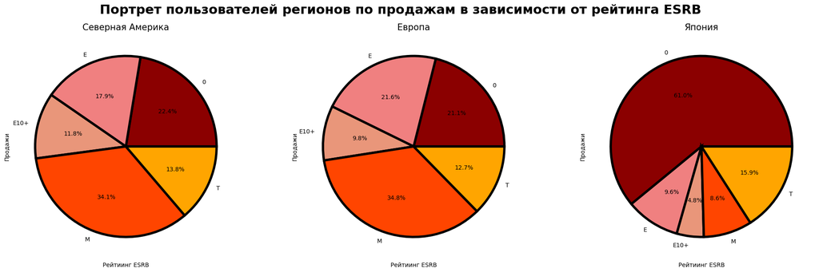

```python
#Выведим три графика распределения продаж между платформами по каждому региону

#Задаем цвета и массивы
regions_rating = [north_america_rating, europe_rating, japan_rating]
reg_data = ["na_sales", "eu_sales", "jp_sales"]
colors = ["darkred", "lightcoral", "darksalmon", "orangered", "orange"]
names = ["Северная Америка", "Европа", "Япония"]
pie_chart_colors = ('lemonchiffon', 'greenyellow', 'lime')


fig, axs = plt.subplots(1, 3, figsize=(25, 7))
fig.suptitle('Портрет пользователей регионов по продажам в зависимости от рейтинга ESRB' + '\n', fontsize=22, fontweight='bold')

for i, ax in enumerate(axs.flat):
    ax.pie(reg_data[i], labels=list(regions_rating[i]["rating"]), autopct='%1.1f%%', colors = colors, data=regions_rating[i], wedgeprops={"edgecolor":"k",'linewidth': 4, 'linestyle': '-', 'antialiased': True})
    ax.set_ylabel('Продажи')
    ax.set_xlabel('Рейтиинг ESRB')
    ax.set_title(names[i])
    ax.title.set_size(15)

plt.show()
```

**Итак, получается, что портреты Американского и Европейского пользователей очеь схожи: они используют кансоли преймуществено заподного производства (PS/Xbox) и ориентируются на возростной рейтинг ESRB. В то время как Японские пользователи чаще используют консоли собственного производства (DS) и очень слабо используют данный рейтинг (видемо имея свой внутренний).**

### Проверка статистических гипотез

Далее выдвенем и проверим две статистические гипотезы относительно пользовательских рейтингов:

```
- Средние пользовательские рейтинги платформ Xbox One и PC одинаковые;

- Средние пользовательские рейтинги жанров Action (англ. «действие», экшен-игры) и Sports (англ. «спортивные соревнования») разные. </strong>
```

В основы проверки гипотез ляжет двувыборочный статистический тест: t-test Стьюдента. Который используется для порверки гипотез о равенсве или различии средних между выборочными совокупностями

#### рейтинги платформ Xbox One и PC

Иток, выдвенем нулевую статистическую гипотезу (H0), которая будет звучать следующим образом: **Средние пользовательские рейтинги платформ Xbox One и PC равны.** Соответственно, альтернативная гипотеза - двусторонняя: **Средние пользовательские рейтинги платформ Xbox One и PC не равны.**

```python
games_test = games.loc[games["no_scored"] == 0]
games_test = games_test.dropna()
games_test.info()
```

```
<class 'pandas.core.frame.DataFrame'>
Index: 6835 entries, 0 to 16702
Data columns (total 13 columns):
 #   Column           Non-Null Count  Dtype
---  ------           --------------  -----
 0   name             6835 non-null   object
 1   platform         6835 non-null   object
 2   year_of_release  6835 non-null   int32
 3   genre            6835 non-null   object
 4   na_sales         6835 non-null   float64
 5   eu_sales         6835 non-null   float64
 6   jp_sales         6835 non-null   float64
 7   other_sales      6835 non-null   float64
 8   critic_score     6835 non-null   float64
 9   user_score       6835 non-null   float64
 10  rating           6835 non-null   object
 11  sum_sales        6835 non-null   float64
 12  no_scored        6835 non-null   int64
dtypes: float64(7), int32(1), int64(1), object(4)
memory usage: 720.9+ KB
```

```python
#Выведем годы начал производств видеоигр на рассматриваемых платформах
print("XOne:", games_test.query("platform == 'XOne'")["year_of_release"].min(),
      "PC:", games_test.query("platform == 'PC'")["year_of_release"].min())
```

```
XOne: 2013 PC: 1985
```

Так, игргы на ПК стали выпускаться гораздо раньше. Для сравнения выборок, возьмем значение в одинаковый временной промежуток

```python
games_test_1 = games_test.loc[games_test["year_of_release"] >= 2013]
```

```python
#Для проверки данной гипотезы необходимо сформировать два массива: Рейтинги Xbox и рейтинги PC:

xbox_ratings = games_test_1.query("platform == 'XOne'")["user_score"]

pc_ratings = games_test_1.query("platform == 'PC'")["user_score"]

print("Среднее значениие по Хbox:", xbox_ratings.mean())
print("Среднее значениие по PC:", pc_ratings.mean())
```

```
Среднее значениие по Хbox: 6.49308176100629
Среднее значениие по PC: 6.235820895522389
```

Уровень статистической значимости alpha будет равняться 0.05 (5%), что является одним из унифицированных значений. Выбор в пользу 5% вместо 1% основан на том, что выборочные данные не большие и получить меньше 1% будет тяжело, поэтому 5ти будет достаточно.

```python
#Здададим уровень статистической значимости
alpha = 0.05

#Осуществим проверку двувыборочным статистическим t-test'ом для двусторонней гипотезы (выборки разные по размеру, так-что дисперсии не приравниваем)
test_result = st.ttest_ind(xbox_ratings, pc_ratings, equal_var=False)

print("p_значение:", test_result.pvalue)

if test_result.pvalue < alpha:
    print("Отвергаем нулевую гипотезу")
else:
    print("Нулевая гипотеза не отвергается")
```

```
p_значение: 0.16694185960105132
Нулевая гипотеза не отвергается
```

Нулевая гипотеза не отвергается, что означает, что наблюдаемые данные статистически не противоречат выдвинутой гипотезе, а значит - средние пользовательский рейтинг платформ Xbox One и PC равны.

*P_значение равняется 0.16 или 16%, что можно интерпретировать таким образом, что с вероятностью 16% наблюдаемое (или большее) различие получается случайно, чего не достаточно (согласно выбранному доверительному интервалу) для того, чтобы предположить верность альтернативной гипотезы об отличии*

**Вывод - Нулевая гипотеза не была отвергнута - рейтинг платформ Xbox One и PC равны.**

```python
# Приведены два датасета: сумма покупок, совершённых за месяц посетителями ...

sample_1 = [3071, 3636, 3454, 3151, 2185, 3259, 1727, 2263, 2015,
2582, 4815, 633, 3186, 887, 2028, 3589, 2564, 1422, 1785,
3180, 1770, 2716, 2546, 1848, 4644, 3134, 475, 2686,
1838, 3352]
sample_2 = [1211, 1228, 2157, 3699, 600, 1898, 1688, 1420, 5048, 3007,
509, 3777, 5583, 3949, 121, 1674, 4300, 1338, 3066,
3562, 1010, 2311, 462, 863, 2021, 528, 1849, 255,
1740, 2596]
alpha = .05 # критический уровень статистической значимости
# если p-value окажется меньше него - отвергнем гипотезу
results = st.ttest_ind(
sample_1,
sample_2)
print('p-значение:', results.pvalue)
if (results.pvalue < alpha):
    print("Отвергаем нулевую гипотезу")
else:
    print("Не получилось отвергнуть нулевую гипотезу")
```

```
p-значение: 0.1912450522572209
Не получилось отвергнуть нулевую гипотезу
```

#### рейтинги жанров Action и Sports

Далее необходимо проверить различность рейтингов двух жанров. **Средние пользовательские рейтинги платформ жанорв Action и Sports не равны.** Однако нулевую гипотезу также выдвенем через cходство средних, а не через различие. Смысл проверки от этого не должен поменяться.

Поэтому выдвегаем нулевую статистическую гипотезу (H0), которая будет звучать следующим образом: **Средние пользовательские рейтинги игр в жанре Action и Sports равны.** Соответственно, альтернативная гипотеза - двусторонняя: **Средние пользовательские рейтинги игр в жанре Action и Sports не равны.**

```python
print("XOne:", games_test.query("genre == 'Action'")["year_of_release"].min(),
      "PC:", games_test.query("genre == 'Sports'")["year_of_release"].min())
```

```
XOne: 1996 PC: 1998
```

Временные промежутки выборок примерно равны, оставим в исходном виде

```python
#Для проверки данной гипотезы необходимо сформировать два массива: Рейтинги Экшена и рейтинги Спротивных игр:
action_rating = games_test.query("genre == 'Action'")["user_score"]

sports_rating = games_test.query("genre == 'Sports'")["user_score"]

print("Среднее значениие по Action:", action_rating.mean())
print("Среднее значениие по Sports:", sports_rating.mean())
```

```
Среднее значениие по Action: 7.096689147762109
Среднее значениие по Sports: 7.1216842105263165
```

```python
#Здададим уровень статистической значимости
alpha = 0.05

#Осуществим проверку двувыборочным статистическим t-test'ом для двусторонней гипотезы
test_result = st.ttest_ind(action_rating, sports_rating, equal_var=False)

print("p_значение:", test_result.pvalue)

if test_result.pvalue < alpha:
    print("Отвергаем нулевую гипотезу")
else:
    print("Нулевая гипотеза не отвергается")
```

```
p_значение: 0.6686293034269601
Нулевая гипотеза не отвергается
```

Нулевая гипотеза не отвергается, что означает, что наблюдаемые данные статистически не противоречат выдвинутой гипотезе, а значит - средние пользовательский рейтинг жанорв Action и Sports равны.

*P_значение равняется 0.66 или 66%, что можно интерпретировать таким образом, что с вероятностью 66% наблюдаемое (или большее) различие между рейтингами получается случайно, чего не достаточно (согласно выбранному доверительному интервалу) для того, чтобы предположить верность альтернативной гипотезы об отличии*

**Вывод: Соответственно, данных для отвержения нулевой гипотезы недостаточно - рейтинги жанорв Action и Sports равны.**

### Общие выводы

Итак, проектная работа по анализу рынка видеоигр позволила провести глубокое исследование данных, выявить основные тренды и закономерности, которые характеризуют данную индустрию. Анализ продаж, платформ, жанров, региональных предпочтений и влияния отзывов на успех игр позволил получить необходимую информацию для разработки стратегий продвижения и маркетинга магазиина видеоигр.

В ходе данной проектной работы были осущетслвены:

1) Импорт и первичный осмотр данных:

- Импортированный массив состоял из **16713 наблюдений**.
- Первичный осмотр данных позволил оценить общую структуру набора информации, которая не вызвала особых вопросов и затруднений

2) Предобработка данных:

- Названия столбцов были исправлены для удобства работы с данными.
- Пропуски в данных были обработаны, дубликаты проверены. В результате работы с пропусками осталосб **16462** наблюдений. Две переменные остались примерно с двумя тысячами пропусков
- Типы данных были скорректированы для дальнейшего анализа в соответствии с необходимостью.
- В качестве новых данных было добавлено агрегированное значение **sum_sales, для работы с общим числом продаж**.

3) Исследовательский анализ данных:

- Активность выпуска видеоигр по годам была выявлена. **Рынок начал функционировать примерно с 1995 года, однако в итоге оказалось, что актуальный для анализа период начинается только с 2014**
- Наиболее успешные компании в выпуске видеоигр к 2017 году были определены. К их числу отнеслись **'3DS', 'PS4', 'PC', 'XOne', 'WiiU'**.
- Изучено изменение продаж по платформам и средний период популярности каждой платформы. *Продажи изменяются в парабалической форме т.е. идут в верх, достигают пика и спадают*. **Средний период популярности отдельной платформы - 10 лет.**
- Потенциальные лидеры на 2017 год были выявлены. К их чеслу были отнесены **PS4' и 'XOne'**, также к активно действующим платформам были отнесены **PC, PS3, WiiU, X360, 3DS**
- Влияние отзывов пользователей и критиков на продажи было проанализировано. Коэффициент корреляции показал, что **покупатели слабо ориентируются на отзывы пользователей об игре. На отзывы критиков - более активно, но также не первостепенно, умеренно. Средний уровень взаимосвязи - 0,33 (измеряется до 1)**.
- Распределение игр по жанрам было исследовано. Самые перспективные жанры: **Шутеры, Спортивные игры и Экшены**

4) Составление портрета пользователя каждого региона:

- Самые популярные платформы и жанры в каждом регионе были определены.
- Влияние рейтинга ESRB на продажи в отдельном регионе было проанализировано.

  портреты Американского и Европейского пользователей очеь схожи: они используют кансоли преймуществено заподного производства (PS/Xbox) и ориентируются на возростной рейтинг ESRB. В то время как Японские пользователи чаще используют консоли собственного производства (DS) и очень слабо используют данный рейтинг

5) Проверка статистических гипотез:

- Была проверена гипотеза о равенстве средних пользовательских рейтингов платформ Xbox One и PC. **Отвергнуть нулевую гипотезу о равенстве не удалось - рейтинг платформ Xbox One и PC не различаются.**
- Была проверена гипотеза о различии средних пользовательских рейтингов жанров Action и Sports. **Нулевую гипотезу отвергуть не удалось, а значит вышепоставленная альтернативная гипотеза не принимается - рейтинги жанорв Action и Sports одинаковы.**

Итоги работы:

В ходе анализа данных были успешно выполнены поставленные задачи, получены ценные выводы о рынке видеоигр, предпочтениях пользователей и влиянии различных факторов на продажи. Результаты анализа помогут принять обоснованные решения в сфере выбора траектории продажи видеоигр.